# 04-CensusVisualization

## Visualizing estimates over time

```r
years <- 2005:2019
names(years) <- years

bernalillo_value <- map_dfr(years, ~{
  get_acs(
    geography = "county",
    variables = "B25077_001",
    state = "New Mexico",
    county = "Bernalillo",
    year = .x,
    survey = "acs1"
  )
}, .id = "year")
bernalillo_value
```

```
## # A tibble: 15 × 6
##    year  GEOID NAME                          variable   estimate   moe
##    <chr> <chr> <chr>                         <chr>         <dbl> <dbl>
##  1 2005  35001 Bernalillo County, New Mexico B25077_001   152400  3060
##  2 2006  35001 Bernalillo County, New Mexico B25077_001   173500  3086
##  3 2007  35001 Bernalillo County, New Mexico B25077_001   185600  3406
##  4 2008  35001 Bernalillo County, New Mexico B25077_001   201900  4553
##  5 2009  35001 Bernalillo County, New Mexico B25077_001   189800  3618
##  6 2010  35001 Bernalillo County, New Mexico B25077_001   192800  3139
##  7 2011  35001 Bernalillo County, New Mexico B25077_001   185100  5771
##  8 2012  35001 Bernalillo County, New Mexico B25077_001   181600  3874
##  9 2013  35001 Bernalillo County, New Mexico B25077_001   185000  3894
## 10 2014  35001 Bernalillo County, New Mexico B25077_001   184600  4412
## 11 2015  35001 Bernalillo County, New Mexico B25077_001   189000  3121
## 12 2016  35001 Bernalillo County, New Mexico B25077_001   194200  5197
## 13 2017  35001 Bernalillo County, New Mexico B25077_001   198000  4999
## 14 2018  35001 Bernalillo County, New Mexico B25077_001   208400  4626
## 15 2019  35001 Bernalillo County, New Mexico B25077_001   210900  4113
```

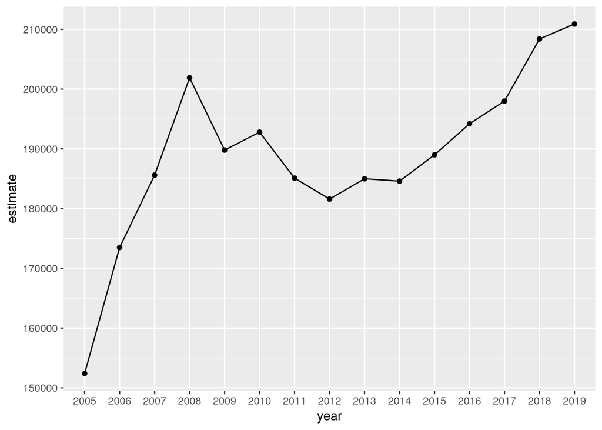

```r
bernalillo_value |>
  ggplot(aes(x = year, y = estimate, group = 1)) +
  geom_line() +
  geom_point()
```

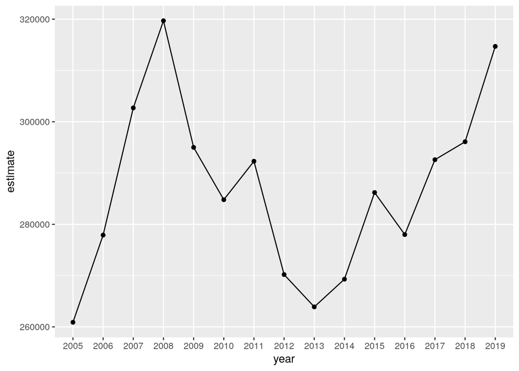

```r
santa_fe_value <- map_dfr(years, ~{
  get_acs(
    geography = "county",
    variables = "B25077_001",
    state = "New Mexico",
    county = "Santa Fe",
    year = .x,
    survey = "acs1"
  )
}, .id = "year")
santa_fe_value |>
  ggplot(aes(x = year, y = estimate, group = 1)) +
  geom_line() +
  geom_point()
```

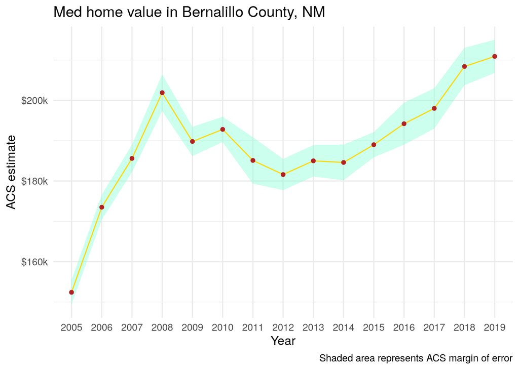

```r
bernalillo_value |>
  ggplot(aes(x = year, y = estimate, group = 1)) +
  geom_ribbon(aes(ymax = estimate + moe, ymin = estimate - moe),
              fill = "aquamarine", alpha = 0.4) +
  geom_line(color = "gold") +
  geom_point(color = "firebrick") +
  theme_minimal(base_size = 12) +
  scale_y_continuous(labels = label_dollar(scale = .001, suffix = "k")) +
  labs(title = "Med home value in Bernalillo County, NM",
       x = "Year",
       y = "ACS estimate",
       caption = "Shaded area represents ACS margin of error")
```

## Population pyramids

Population pyramids are typically constructed by visualizing population size or proportion on the x-axis; age cohort on the y-axis; and sex is represented categorically with male and female bars mirrored around a central axis.

```r
nm <- get_estimates(
  geography = "state",
  state = "NM",
  product = "characteristics",
  breakdown = c("SEX", "AGEGROUP"),
  breakdown_labels = T,
  year = 2019
)
nm
```

```
## # A tibble: 96 × 5
##    GEOID NAME         value SEX        AGEGROUP
##    <chr> <chr>        <dbl> <chr>      <fct>
##  1 35    New Mexico 2096829 Both sexes All ages
##  2 35    New Mexico  120986 Both sexes Age 0 to 4 years
##  3 35    New Mexico  132779 Both sexes Age 5 to 9 years
##  4 35    New Mexico 1037432 Male       All ages
##  5 35    New Mexico   67810 Male       Age 5 to 9 years
##  6 35    New Mexico 1059397 Female     All ages
##  7 35    New Mexico   64969 Female     Age 5 to 9 years
##  8 35    New Mexico   24468 Female     Age 80 to 84 years
##  9 35    New Mexico  139489 Both sexes Age 10 to 14 years
## 10 35    New Mexico   70811 Male       Age 10 to 14 years
## # ℹ 86 more rows
```

> Processing
> - remove “Both sexes” rows
> - remove rows for “All ages”
> - to achieve the mirroring, convert all Male values to negative

```r
nm_filtered <- nm |>
  filter(str_detect(AGEGROUP, "^Age"),
         SEX != "Both sexes") |>
  mutate(value = ifelse(SEX == "Male", -value, value))
nm_filtered
```

```
## # A tibble: 36 × 5
##    GEOID NAME        value SEX    AGEGROUP
##    <chr> <chr>       <dbl> <chr>  <fct>
##  1 35    New Mexico -67810 Male   Age 5 to 9 years
##  2 35    New Mexico  64969 Female Age 5 to 9 years
##  3 35    New Mexico  24468 Female Age 80 to 84 years
##  4 35    New Mexico -70811 Male   Age 10 to 14 years
##  5 35    New Mexico -70557 Male   Age 15 to 19 years
##  6 35    New Mexico  68678 Female Age 10 to 14 years
##  7 35    New Mexico  67901 Female Age 15 to 19 years
##  8 35    New Mexico -72869 Male   Age 20 to 24 years
##  9 35    New Mexico  67132 Female Age 20 to 24 years
## 10 35    New Mexico -71278 Male   Age 30 to 34 years
## # ℹ 26 more rows
```

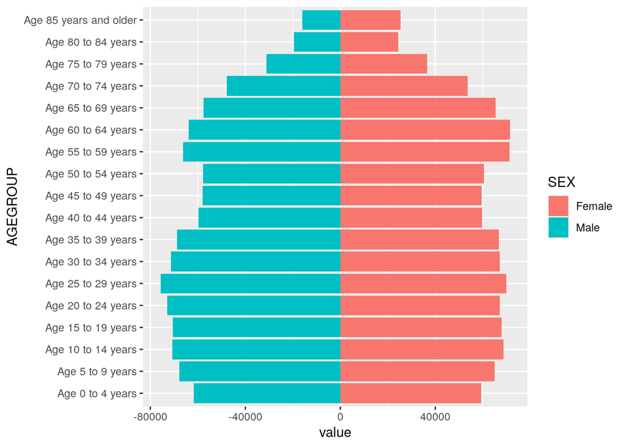

```r
nm_filtered |>
  ggplot(aes(x = value, y = AGEGROUP, fill = SEX)) +
  geom_col()
```

- specify appropriate chart labels
- format the axis tick labels by using appropriate `scale_*` functions
- set the X-axis limits to show both sides of 0 equally. In particular, this involves the use of custom absolute values to represent population sizes, and the removal of redundant age group information
- use [`theme_minimal()`](https://ggplot2.tidyverse.org/reference/ggtheme.html), which uses a white background with muted gridlines.

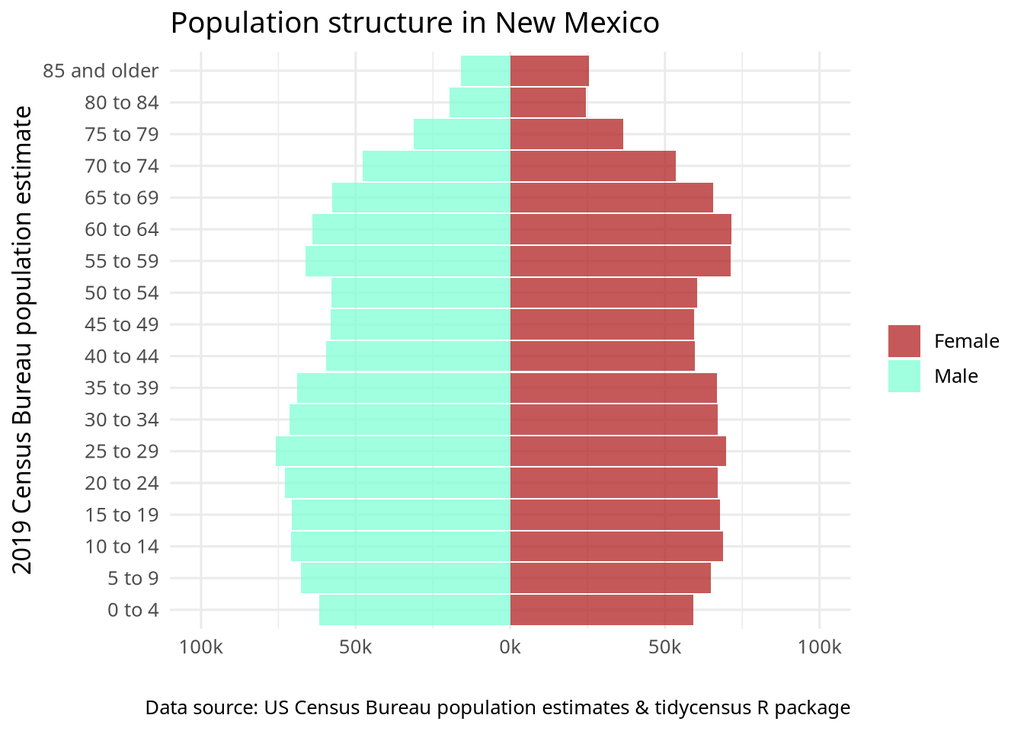

```r
nm_pyramid <- nm_filtered |>
  ggplot(aes(y = AGEGROUP,
             x = value,
             fill = SEX)) +
  geom_col(width = 0.95, alpha = 0.75) +
  theme_minimal(base_family = "Verdana", base_size = 12) +
  scale_x_continuous(
    labels = ~ number_format(scale = .001, suffix = "k")(abs(.x)),
    limits = 100000 * c(-1,1)
  ) +
  scale_y_discrete(labels = ~ str_remove_all(.x, "Age\\s|\\syears")) +
  scale_fill_manual(values = c("firebrick","aquamarine")) +
  labs(x = "",
       y = "2019 Census Bureau population estimate",
       title = "Population structure in New Mexico",
       fill = "",
       caption = "Data source: US Census Bureau population estimates & tidycensus R package")
nm_pyramid
```